# Técnicas de reducción de varianza

# Condicionamiento

1. Sea $W\sim Poisson(10)$ y $(X|W=w) \sim Beta(w,w^2+1)$. Encontrar la media no condicional $\theta = E(X)$.
2. Un proyecto de construcción tiene una duración $X|(\mu,\sigma^2) \sim \mathcal{N}(\mu,\sigma^2)$ donde $\mu \sim \mathcal{N}(100,16)$ y $\sigma^2\sim exp(1/4)$, con $\mu \perp \sigma^2$. La compañía que construye debe pagar 1000 USD por cada día (y prorata por partes de día) que la duración del proyecto excede $K$ días. ¿Cuál es el costo esperado del retraso?
- Calcular usando MC usual y usando condicionamiento.
- Comparar varianzas

# Muestreo de importancia

1. Consideren $\int_0^1\frac{e^{-x}}{1+x^2}\, dx$ y cuatro funciones de importancia:
- $g_0(x) = I_{[0,1]}(x)$
- $g_1(x) = e^{-x}$
- $g_2(x) = \frac{\pi}{1+x^2}$
- $g_3(x) = \frac{e^{-x}}{1-e^{-1}}$

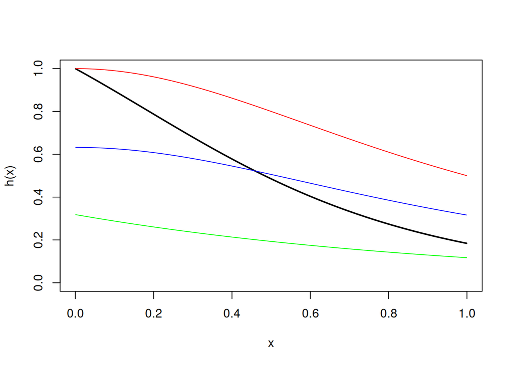

```r
h <- function(x)exp(-x-log(1+x^2))*(x>0)*(x<1)
g0 <- function(x)ifelse(x>0 & x<1,1,0)
g1 <- function(x)exp(-x)
g2 <- function(x)pi/(1+x^2)
g3 <- function(x)exp(-x)/(1-exp(-1))

#gráficas
curve(h(x),from=0.001, to=0.999, lwd=2, ylim=c(0,1))
curve(h(x)/g1(x),from=0.001,to=0.999,col="red",add=T)
curve(h(x)/g2(x),from=0.001,to=0.999,col="green",add=T)
curve(h(x)/g3(x),from=0.001,to=0.999,col="blue",add=T)
```

2. Calculen $P(X>20)$ cuando $X\sim N(0,1)$.

# Muestreo estratificado

1. Consideren otra vez $\int_0^1\frac{e^{-x}}{1+x^2}\, dx$ y apliquen muestreo estratificado.